# Text mining avec TidyText sous R

## Chargement et inspection de la base

#### Chargement

```r
#vider la mémoire
rm(list=ls())

#changer de dossier courant
setwd("C:/Users/ricco/Desktop/demo")

#charger les packages de l'univers Tidy
#en particulier dplyr
library(tidyverse)
#charger les données
#avec le package readxl
D <- readxl::read_excel("imdb_reviews_1000.xlsx")
str(D)
```

```
## tibble [2,000 x 2] (S3: tbl_df/tbl/data.frame)
##  $ label       : chr [1:2000] "neg" "neg" "neg" "neg" ...
##  $ commentaires: chr [1:2000] "I don't have much to say about this movie. It could have been a wonderful tour-de-force for Peter Sellers, but "| __truncated__ "Race car drivers say that 100 mph seems fast till you've driven 150, and 150 mph seems fast till you've driven "| __truncated__ "I found …
```

```r
#premiers documents de la base de données
head(D)
```

| label | commentaires |
| --- | --- |
| neg | I don't have much to say about this movie. It could have been a wonderful tour-de-force for Peter Sellers, but it is one of the most tragic misfires in movie history. That it was Sellers final movie m… |
| neg | Race car drivers say that 100 mph seems fast till you've driven 150, and 150 mph seems fast till you've driven 250.OK.Andalusian Dog seems breathtakingly bizarre till you've seen Eraserhead, and Erase… |
| neg | I found this film to be quite an oddity. From the very get go I found it extremely hard to like this movie, and now after a little thinking about it I can pretty much pinpoint the reason why. Jean-Mar… |
| neg | Jane Russell proved to be a delightful musical-comedy performer in the similarly titled "Gentlemen Prefer Blondes" but, sadly, this film squanders those skills. There is a budget, and nice Paris photo… |
| neg | This movie makes Canadians and Brits out to be asinine, moronic idiots. The men get stoned/drunk, and then they yell/beat each other up in almost every scene. The women are superfluous to the story I … |
| neg | I'm a great admirer of Lon Chaney, but the screen writing of this movie just did not work for me. The story jumps around oddly (I've since learned that the film is missing a section), and characters a… |

```r
#inspection des classes
print(table(D$label))
```

```
##
##  neg  pos
## 1000 1000
```

#### Quelques vérifications supplémentaires

Présence de la **balise HTML “saut de ligne”** dans les commentaires.

```r
#présence des '<br />' dans les commentaires
tmp <- grep("<br />",D$commentaires)
print(length(tmp))
```

```
## [1] 1190
```

```r
#lequels
print(head(tmp))
```

```
## [1]  1  2  4  5  8 10
```

```r
#le premier par ex.
print(D$commentaires[1])
```

```
## [1] "I don't have much to say about this movie. It could have been a wonderful tour-de-force for Peter Sellers, but it is one of the most tragic misfires in movie history. That it was Sellers final movie makes it all the more painful.<br /><br />The terrible screenplay, direction and shockingly w…
```

```r
#le troisième par ex.
print(D$commentaires[3])
```

```
## [1] "I found this film to be quite an oddity. From the very get go I found it extremely hard to like this movie, and now after a little thinking about it I can pretty much pinpoint the reason why. Jean-Marc Barr, although I love him to bits (I think Zentropa is one of the best movies ever made) i…
```

Présence de **chiffres** dans les commentaires.

```r
#présence des chiffres
#cf. expressions régulières sous R
#http://tutoriels-data-mining.blogspot.com/2017/01/les-expression-regulieres-sous-r.html
tmp <- grep('[0-9]',D$commentaires)
print(length(tmp))
```

```
## [1] 1139
```

```r
#lesquels
print(head(tmp))
```

```
## [1]  2  4  8  9 10 12
```

```r
#le 2ème message
print(D$commentaires[2])
```

```
## [1] "Race car drivers say that 100 mph seems fast till you've driven 150, and 150 mph seems fast till you've driven 250.<br /><br />OK.<br /><br />Andalusian Dog seems breathtakingly bizarre till you've seen Eraserhead, and Eraserhead seems breathtakingly bizarre till you've seen Begotten.<br /><…
```

```r
#le premier
print(D$commentaires[1])
```

```
## [1] "I don't have much to say about this movie. It could have been a wonderful tour-de-force for Peter Sellers, but it is one of the most tragic misfires in movie history. That it was Sellers final movie makes it all the more painful.<br /><br />The terrible screenplay, direction and shockingly w…
```

## TidyText - Premières explorations

#### Préparation des données

```r
#charger spécifiquement la libraire tidytext
library(tidytext)
```

La numérotation des documents permet de mieux comprendre les associations des termes avec les documents par la suite.

```r
#modifier la structure du tibble
#en numérotant les documents
DPRIM <- tibble(line=1:nrow(D),commentaires=D$commentaires)
print(head(DPRIM))
```

```
## # A tibble: 6 x 2
##    line commentaires
##   <int> <chr>
## 1     1 "I don't have much to say about this movie. It could have been a wonder~
## 2     2 "Race car drivers say that 100 mph seems fast till you've driven 150, a~
## 3     3 "I found this film to be quite an oddity. From the very get go I found ~
## 4     4 "Jane Russell proved to be a delightful musical-comedy performer in the~
## 5     5 "This movie makes Canadians and Brits out to be asinine, moronic idiots~
## 6     6 "I'm a great admirer of Lon Chaney, but the screen writing of this movi~
```

#### Tokenisation

Transformation des documents en une structure “tidy”, en recensant les mots par document. L’information sur l’ordre des mots est perdue. On note en revanche que la casse a été changée, la ponctuation a été supprimée.

```r
#traiter le texte brut
res_A <- DPRIM %>%
  unnest_tokens(output=word,input=commentaires)

#
print(res_A)
```

```
## # A tibble: 467,429 x 2
##     line word
##    <int> <chr>
##  1     1 i
##  2     1 don't
##  3     1 have
##  4     1 much
##  5     1 to
##  6     1 say
##  7     1 about
##  8     1 this
##  9     1 movie
## 10     1 it
## # ... with 467,419 more rows
```

#### Inspection du 1er document

```r
#si on s'en tient aux mots du premier document
mots_1 <- res_A %>%
  filter(line==1) %>%
  select(word)

print(mots_1$word)
```

```
##   [1] "i"            "don't"        "have"         "much"         "to"
##   [6] "say"          "about"        "this"         "movie"        "it"
##  [11] "could"        "have"         "been"         "a"            "wonderful"
##  [16] "tour"         "de"           "force"        "for"          "peter"
##  [21] "sellers"      "but"          "it"           "is"           "one"
##  [26] "of"           "the"          "most"         "tragic"       "misfires"
##  [31] "in"           "movie"        "history"      "that"         "it"
##  [36] "was"          "sellers"      "final"        "movie"        "makes"
##  [41] "it"           "all"          "the"          "more"         "painful"
##  [46] "br"           "br"           "the"          "terrible"     "screenplay"
##  [51] "direction"    "and"          "shockingly"   "wooden"       "performances"
##  [56] "all"          "come"         "dreadfully"   "together"     "to"
##  [61] "make"         "this"         "one"          "of"           "the"
##  [66] "most"         "unwatchably"  "awful"        "movies"       "ever"
##  [71] "made"         "br"           "br"           "i"            "wish"
##  [76] "so"           "much"         "that"         "i"            "could"
##  [81] "find"         "even"         "a"            "snicker"      "or"
##  [86] "a"            "chuckle"      "buried"       "somewhere"    "in"
##  [91] "this"         "pile"         "of"           "putrid"       "blubber"
##  [96] "but"          "it's"         "a"            "lifeless"     "humorless"
## [101] "disaster"     "the"          "truth"        "hurts"        "br"
## [106] "br"           "peter"        "why"          "couldn't"     "you"
## [111] "have"         "stopped"      "at"           "being"        "there"
```

```r
#pour rappel le 1er document était...
print(D$commentaires[1])
```

```
## [1] "I don't have much to say about this movie. It could have been a wonderful tour-de-force for Peter Sellers, but it is one of the most tragic misfires in movie history. That it was Sellers final movie makes it all the more painful.<br /><br />The terrible screenplay, direction and shockingly w…
```

#### Fréquence des termes dans les documents

```r
#dans le premier document
mots_1 %>%
  group_by(word) %>%
  count(sort=TRUE)
```

| word | n |
| --- | --- |
| br | 6 |
| the | 5 |
| a | 4 |
| it | 4 |
| have | 3 |
| i | 3 |
| movie | 3 |
| of | 3 |
| this | 3 |
| all | 2 |

[output cut: 69 more lines]

```r
#comptage des termes par document
compte_A <- res_A %>%
  group_by(line,word) %>%
  summarize(freq=n())
print(compte_A)
```

```
## # A tibble: 281,109 x 3
## # Groups:   line [2,000]
##     line word     freq
##    <int> <chr>   <int>
##  1     1 a           4
##  2     1 about       1
##  3     1 all         2
##  4     1 and         1
##  5     1 at          1
##  6     1 awful       1
##  7     1 been        1
##  8     1 being       1
##  9     1 blubber     1
## 10     1 br          6
## # ... with 281,099 more rows
```

#### Dictionnaire global des termes

```r
#dictionnaire - comptage
#ordonnancement selon la fréquence
dico_A <- res_A %>%
  count(word,sort=TRUE)

#affichage
print(dico_A)
```

```
## # A tibble: 26,495 x 2
##    word      n
##    <chr> <int>
##  1 the   26766
##  2 and   12860
##  3 a     12706
##  4 of    11611
##  5 to    10527
##  6 is     8443
##  7 br     8258
##  8 in     7454
##  9 it     6289
## 10 i      6100
## # ... with 26,485 more rows
```

```r
#les termes les moins fréquents
print(tail(dico_A))
```

```
## # A tibble: 6 x 2
##   word         n
##   <chr>    <int>
## 1 zorro        1
## 2 zouzou       1
## 3 zucker       1
## 4 zues         1
## 5 zunz         1
## 6 zvonimir     1
```

## TidyText - Nettoyage des données

#### Stopwords (mots-vides)

Librairie pour les stopwords en anglais.

```r
#récupération des stopwords
data("stop_words")
print(stop_words)
```

```
## # A tibble: 1,149 x 2
##    word        lexicon
##    <chr>       <chr>
##  1 a           SMART
##  2 a's         SMART
##  3 able        SMART
##  4 about       SMART
##  5 above       SMART
##  6 according   SMART
##  7 accordingly SMART
##  8 across      SMART
##  9 actually    SMART
## 10 after       SMART
## # ... with 1,139 more rows
```

#### Seconde version de la tokenisation

Sans les chiffres, la balise “saut de ligne” et les stopwords.

```r
#deuxième version, sans les chiffres et les br
res_B <- DPRIM %>%
  mutate(text=gsub(x=commentaires,pattern="[0-9]",replacement="")) %>%
  mutate(text=gsub(x=text,pattern="<br />",replacement="")) %>%
  unnest_tokens(output=word,input=text) %>%
  filter(!word %in% stop_words$word) %>%
  select(line,word)

#affichage
print(res_B)
```

```
## # A tibble: 172,664 x 2
##     line word
##    <int> <chr>
##  1     1 movie
##  2     1 wonderful
##  3     1 tour
##  4     1 de
##  5     1 force
##  6     1 peter
##  7     1 sellers
##  8     1 tragic
##  9     1 misfires
## 10     1 movie
## # ... with 172,654 more rows
```

```r
#vérification pour le premier document
print(res_B[res_B$line==1,]$word)
```

```
##  [1] "movie"        "wonderful"    "tour"         "de"           "force"
##  [6] "peter"        "sellers"      "tragic"       "misfires"     "movie"
## [11] "history"      "sellers"      "final"        "movie"        "makes"
## [16] "painful.the"  "terrible"     "screenplay"   "direction"    "shockingly"
## [21] "wooden"       "performances" "dreadfully"   "unwatchably"  "awful"
## [26] "movies"       "made.i"       "snicker"      "chuckle"      "buried"
## [31] "pile"         "putrid"       "blubber"      "lifeless"     "humorless"
## [36] "disaster"     "truth"        "hurts.peter"  "stopped"
```

```r
#par comparaison
DPRIM$commentaires[1]
```

```
## [1] "I don't have much to say about this movie. It could have been a wonderful tour-de-force for Peter Sellers, but it is one of the most tragic misfires in movie history. That it was Sellers final movie makes it all the more painful.<br /><br />The terrible screenplay, direction and shockingly w…
```

#### Dictionnaire des termes

```r
#dictionnaire
dico_B <- res_B %>%
  count(word,sort=TRUE)

print(dico_B)
```

```
## # A tibble: 27,759 x 2
##    word           n
##    <chr>      <int>
##  1 movie       3421
##  2 film        2991
##  3 time         912
##  4 story        906
##  5 people       747
##  6 bad          706
##  7 characters   560
##  8 movies       547
##  9 films        542
## 10 watch        526
## # ... with 27,749 more rows
```

Avec un petit “wordcloud” pour faire joli…

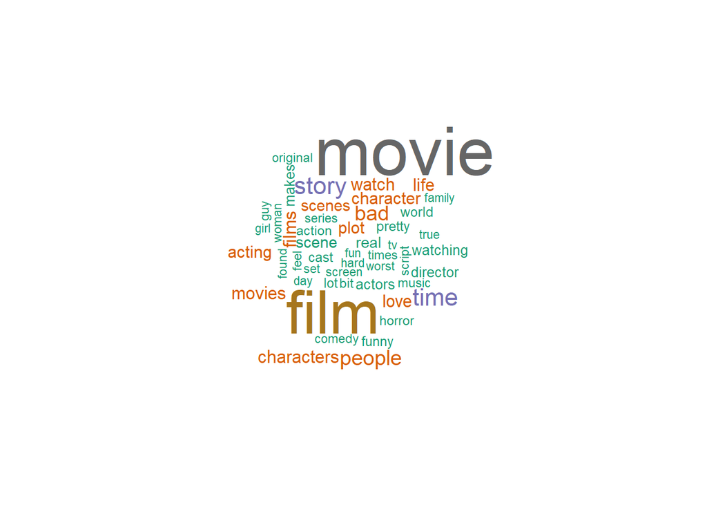

```r
#un petit wordcloud ici
library(wordcloud)
wordcloud(words=dico_B$word,freq=dico_B$n,max.word=50,colors = brewer.pal(8,'Dark2'))
```

#### Matrice documents-termes

Une matrice avec en ligne les documents, en colonne les termes, et en valeurs la fréquence des termes dans les documents.

```r
#rappel structure tidy
print(head(res_B))
```

```
## # A tibble: 6 x 2
##    line word
##   <int> <chr>
## 1     1 movie
## 2     1 wonderful
## 3     1 tour
## 4     1 de
## 5     1 force
## 6     1 peter
```

```r
#comptage des termes par document
compte_B <- res_B %>%
  group_by(line,word) %>%
  summarize(freq=n())
print(compte_B)
```

```
## # A tibble: 145,871 x 3
## # Groups:   line [2,000]
##     line word        freq
##    <int> <chr>      <int>
##  1     1 awful          1
##  2     1 blubber        1
##  3     1 buried         1
##  4     1 chuckle        1
##  5     1 de             1
##  6     1 direction      1
##  7     1 disaster       1
##  8     1 dreadfully     1
##  9     1 final          1
## 10     1 force          1
## # ... with 145,861 more rows
```

```r
#nécessité de disposer de la librairie "tm"
library(tm)
#"cast" en MDT (pondération = fréquence)
#autre pondération possible, ex. TF-IDF
#cf. https://www.rdocumentation.org/packages/tidytext/versions/0.3.2/topics/bind_tf_idf
mdt_B <- compte_B %>%
  cast_dtm(document = line, term = word, value = freq)

#affichage
print(mdt_B)
```

```
## <<DocumentTermMatrix (documents: 2000, terms: 27759)>>
## Non-/sparse entries: 145871/55372129
## Sparsity           : 100%
## Maximal term length: 36
## Weighting          : term frequency (tf)
```

```r
#dans un format "matrix"
#plus facile à manipuler pour nous
mat_B <- as.matrix(mdt_B)

#classe
print(class(mat_B))
```

```
## [1] "matrix" "array"
```

```r
#dimension
print(dim(mat_B))
```

```
## [1]  2000 27759
```

```r
#comptage des termes pour le document 1
print(mat_B[1,which(mat_B[1,]>0)])
```

```
##        awful      blubber       buried      chuckle           de    direction
##            1            1            1            1            1            1
##     disaster   dreadfully        final        force      history    humorless
##            1            1            1            1            1            1
##  hurts.peter     lifeless       made.i        makes     misfires        movie
##            1            1            1            1            1            3
##       movies  painful.the performances        peter         pile       putrid
##            1            1            1            1            1            1
##   screenplay      sellers   shockingly      snicker      stopped     terrible
##            1            2            1            1            1            1
##         tour       tragic        truth  unwatchably    wonderful       wooden
##            1            1            1            1            1            1
```

```r
#vérifions
tmp <- compte_B %>%
  filter(line==1)

#affichage
tmpvec <- tmp$freq
names(tmpvec) <- tmp$word
print(tmpvec)
```

```
##        awful      blubber       buried      chuckle           de    direction
##            1            1            1            1            1            1
##     disaster   dreadfully        final        force      history    humorless
##            1            1            1            1            1            1
##  hurts.peter     lifeless       made.i        makes     misfires        movie
##            1            1            1            1            1            3
##       movies  painful.the performances        peter         pile       putrid
##            1            1            1            1            1            1
##   screenplay      sellers   shockingly      snicker      stopped     terrible
##            1            2            1            1            1            1
##         tour       tragic        truth  unwatchably    wonderful       wooden
##            1            1            1            1            1            1
```

#### Dictionnaire et fréquence des termes

```r
#pour rappel
head(dico_B,20)
```

| word | n |
| --- | --- |
| movie | 3421 |
| film | 2991 |
| time | 912 |
| story | 906 |
| people | 747 |
| bad | 706 |
| characters | 560 |
| movies | 547 |
| films | 542 |
| watch | 526 |

[output cut: 10 more lines]

Refaire le calcul à partir de la matrice documents-termes.

```r
print(head(sort(colSums(mat_B),decreasing=TRUE),20))
```

```
##      movie       film       time      story     people        bad characters
##       3421       2991        912        906        747        706        560
##     movies      films      watch       life       love  character       plot
##        547        542        526        525        510        498        489
##     acting     scenes      scene       real     actors   watching
##        489        439        424        386        350        331
```

#### Apparition des termes dans les documents

Nombre de documents où les termes apparaissent au moins une fois.

```r
#comptage des doc.
app_termes <- apply(mat_B,2,function(x){sum(x>0)})

#affichage trié
print(head(sort(app_termes,decreasing=TRUE),20))
```

```
##      movie       film       time      story     people        bad      watch
##       1204       1085        653        619        489        461        434
##     acting characters     movies       plot      films       life  character
##        411        407        392        386        372        369        368
##       love     scenes      scene       real      makes     actors
##        362        314        308        307        284        277
```

#### Filtrage selon la fréquence

Retirer de la matrice les termes qui apparaissent dans trop peu ou trop nombreux documents.

```r
#condition sur les colonnes
mat_B_filtered <- mat_B[,app_termes > 10 & app_termes <1000]

#dimensions
print(dim(mat_B_filtered))
```

```
## [1] 2000 2529
```

## Analyse via la matrice documents-termes

Quelques pistes pour éexploiter la matrice documents-termes.

#### Polarité observée des termes

N’oublions pas que les documents sont étiquetés (commentaires positifs ou négatifs). L’idée est de déterminer si les termes sont plus souvent associés à des documents positifs ou négatifs.

On ne travaille que sur les termes filtrés, avec la pondération binaire.

```r
#pondération binaire
mat_C <- ifelse(mat_B_filtered>0,1,0)

#transformer la matrice en data.frame
df_C <- as.data.frame(mat_C)
print(class(df_C))
```

```
## [1] "data.frame"
```

```r
#calcul conditionnel
sum_per_class <- aggregate(x=df_C,by=list(D$label),sum)
print(sum_per_class[,1:15])
```

```
##   Group.1 awful de direction disaster final force history makes movies
## 1     neg    92 13        57       17    34    12      36   119    217
## 2     pos    12 16        53        9    53    24      42   165    175
##   performances peter pile screenplay stopped
## 1           43    22   12         21       8
## 2           95    22    0         19       8
```

```r
#structure temporaire
tmp <- as.matrix(sum_per_class[,2:ncol(sum_per_class)])
row.names(tmp) <- sum_per_class$Group.1

#proportion des positifs
prop_pos <- tmp['pos',]/colSums(tmp)
print(sort(prop_pos)[1:15])
```

```
##       pile      sucks  atrocious    rubbish    figured  redeeming     poorly
## 0.00000000 0.00000000 0.00000000 0.00000000 0.00000000 0.03703704 0.04166667
##       clue      waste  stupidity       soap     horrid amateurish       mess
## 0.05000000 0.05940594 0.06250000 0.07142857 0.07692308 0.07692308 0.08163265
##      chick
## 0.08333333
```

```r
#ex. le cas de 'waste'
print(tmp[,'waste'])
```

```
## neg pos
##  95   6
```

#### Schéma explicatif - Arbres de décision

On n’est pas vraiment dans un schéma prédictif, mais plutôt dans la description. Sinon, il faudrait repenser le processus de préparation des données.

```r
#construire un arbre de décision
library(rpart)
arbre <- rpart(D$label ~ ., data = df_C)
print(arbre)
```

```
## n= 2000
##
## node), split, n, loss, yval, (yprob)
##       * denotes terminal node
##
##   1) root 2000 1000 neg (0.5000000 0.5000000)
##     2) bad>=0.5 461  116 neg (0.7483731 0.2516269) *
##     3) bad< 0.5 1539  655 pos (0.4256010 0.5743990)
##       6) worst>=0.5 104   16 neg (0.8461538 0.1538462) *
##       7) worst< 0.5 1435  567 pos (0.3951220 0.6048780)
##        14) waste>=0.5 48    3 neg (0.9375000 0.0625000) *
##        15) waste< 0.5 1387  522 pos (0.3763518 0.6236482)
##          30) boring>=0.5 66   13 neg (0.8030303 0.1969697) *
##          31) boring< 0.5 1321  469 pos (0.3550341 0.6449659)
##            62) plot>=0.5 226  102 neg (0.5486726 0.4513274)
##             124) films< 0.5 163   58 neg (0.6441718 0.3558282) *
##             125) films>=0.5 63   19 pos (0.3015873 0.6984127) *
##            63) plot< 0.5 1095  345 pos (0.3150685 0.6849315)
##             126) awful>=0.5 27    4 neg (0.8518519 0.1481481) *
##             127) awful< 0.5 1068  322 pos (0.3014981 0.6985019) *
```

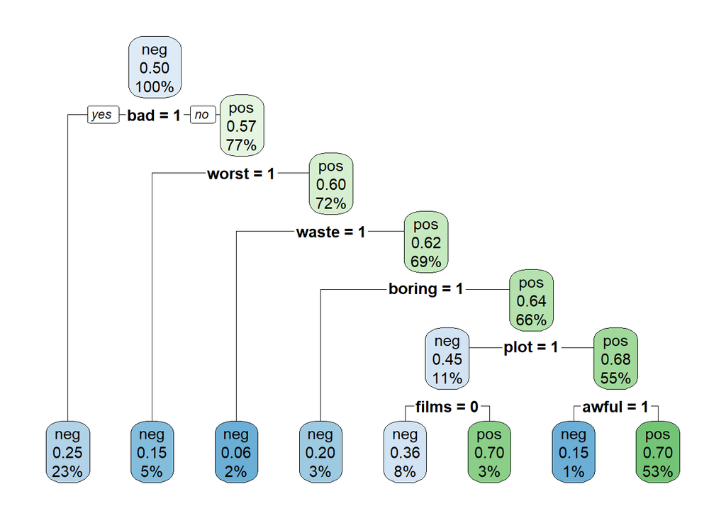

```r
#affichage plus sympathique
library(rpart.plot)
rpart.plot(arbre)
```

```r
#proportion de documents positifs pour les "pires" termes
print(prop_pos[c('bad','worst','waste','boring')])
```

```
##        bad      worst      waste     boring
## 0.25162690 0.12371134 0.05940594 0.17699115
```

## Analyse des sentiments (traditionnelle)

S’intéresser aux polarités de termes pour inférer sur la polarité des documents.

#### Lexique des sentiments

```r
#lexique pour l'analyse des sentiments
#polarité des termes - get_sentiments() de tidtytext
#"bing" est une source possible, il y en a d'autres
polarite_termes <- get_sentiments("bing")
print(polarite_termes)
```

```
## # A tibble: 6,786 x 2
##    word        sentiment
##    <chr>       <chr>
##  1 2-faces     negative
##  2 abnormal    negative
##  3 abolish     negative
##  4 abominable  negative
##  5 abominably  negative
##  6 abominate   negative
##  7 abomination negative
##  8 abort       negative
##  9 aborted     negative
## 10 aborts      negative
## # ... with 6,776 more rows
```

#### Polarité des documents

Polarité d’un document = aggrégation de la polarité des termes qui le compose… s’ils sont recensés bien sûr. Pas besoin de partition apprentissage-test ici parce que la classe (label) n’est pas mise à contribution lors de la “modélisation”. L’approche est non-supervisée par nature, pas de risque de surapprentissage.

Calcul de la polarité des documents par utilisation du lexique des sentiments. Etape par étape.

```r
#recensement des termes par document
res_B %>%
  filter(line==1)
```

| line | word |
| --- | --- |
| 1 | movie |
| 1 | wonderful |
| 1 | tour |
| 1 | de |
| 1 | force |
| 1 | peter |
| 1 | sellers |
| 1 | tragic |
| 1 | misfires |
| 1 | movie |

[output cut: 29 more lines]

```r
#pour un document, jointure avec le lexique
res_B %>%
  filter(line==1) %>%
  left_join(polarite_termes,by="word")
```

| line | word | sentiment |
| --- | --- | --- |
| 1 | movie | NA |
| 1 | wonderful | positive |
| 1 | tour | NA |
| 1 | de | NA |
| 1 | force | NA |
| 1 | peter | NA |
| 1 | sellers | NA |
| 1 | tragic | negative |
| 1 | misfires | NA |
| 1 | movie | NA |

[output cut: 29 more lines]

```r
#retrait des NA, à ne pas comptabiliser
res_B %>%
  filter(line==1) %>%
  left_join(polarite_termes,by="word") %>%
  filter(!is.na(sentiment))
```

| line | word | sentiment |
| --- | --- | --- |
| 1 | wonderful | positive |
| 1 | tragic | negative |
| 1 | terrible | negative |
| 1 | shockingly | negative |
| 1 | dreadfully | negative |
| 1 | awful | negative |
| 1 | lifeless | negative |
| 1 | disaster | negative |

```r
#comptabilisation des polarités
res_B %>%
  filter(line==1) %>%
  left_join(polarite_termes,by="word") %>%
  filter(!is.na(sentiment)) %>%
  count(sentiment)
```

| sentiment | n |
| --- | --- |
| negative | 7 |
| positive | 1 |

Il ne reste plus qu’à réaliser l’opération sur l’ensemble des documents.

```r
#polarité des documents déduite des termes
#qui les composent
#--> proportion des termes positifs
pol_per_doc <- res_B %>%
  group_by(line) %>%
  left_join(polarite_termes,by="word") %>%
  filter(!is.na(sentiment)) %>%
  count(sentiment) %>%
  summarise(freq_pos=n[sentiment=='positive']/sum(n))
#affichage
print(pol_per_doc)
```

```
## # A tibble: 1,916 x 2
## # Groups:   line [1,916]
##     line freq_pos
##    <int>    <dbl>
##  1     1    0.125
##  2     2    0.444
##  3     3    0.375
##  4     4    0.375
##  5     5    0.185
##  6     6    0.429
##  7     7    0.321
##  8     8    0.3
##  9     9    0.231
## 10    10    0.1
## # ... with 1,906 more rows
```

Attention, certains documents ne sont pas recensés (1916 documents notés en tout) parce qu’ils ne présentent aucun terme “positif”.

Prédiction par comparaison avec le seuil 0.5 c.-à-d. est considéré comme positif un commentaire s’il est composé au moins pour moitié de termes positifs.

```r
#prédiction sur cette base
pred_polarite <- rep(0,nrow(D))

#affectation -- ternir compte des doc. non recensés
pred_polarite[pol_per_doc$line] <- pol_per_doc$freq_pos

#classe prédite
class_pred_polarite <- ifelse(pred_polarite >= 0.5,"positive","negative")
print(table(class_pred_polarite))
```

```
## class_pred_polarite
## negative positive
##     1250      750
```

Confrontation avec les classes observées.

```r
#matrice de confusion
mc <-table(D$label,class_pred_polarite)
print(mc)
```

```
##      class_pred_polarite
##       negative positive
##   neg      846      154
##   pos      404      596
```

```r
#accuracy
print(sum(diag(mc))/sum(mc))
```

```
## [1] 0.721
```